# Online Shopping Sales

Ashley Patino

2024-11-12

# Introduction:

Online shopping has become more popular, people love to shop online since it is faster and convenient. It is easier to compare prices and research products. You can save yourself time and gas and not have to wait in long lines. All it takes is your phone/computer and your card and you can happily shop online. We are going to look at customer’s shopping behaviors from data that I found on Kaggle. We will take a look into specific information like on what categories people shop for and how much people spend. The data I am working with is from Kaggle.*https://www.kaggle.com/datasets/shreyanshverma27/online-sales-dataset-popular-marketplace-data?resource=download* The data is made by Shreyanshverma27, who collected the data about 6 months ago, to explore shopping trends in the marketplace and get a better understand of data analysis.

### Loading in the data

```r
# loading package to clean up data
library(tidyverse)
# loading package to use for visual plots and working with data
library(ggplot2)
library(dplyr)

# loading in the data
Online_Sales_Data <- read.csv("Online Sales Data.csv", stringsAsFactors = T)

#re-arranging the dates
Online_Sales_Data <- Online_Sales_Data %>% mutate(shop_date = ymd(Date))
```

### Showing the unfiltered data

```r
# getting a glimpse
glimpse(Online_Sales_Data)
```

```
## Rows: 240
## Columns: 10
## $ Transaction.ID   <int> 10001, 10002, 10003, 10004, 10005, 10006, 10007, 1000…
## $ Date             <fct> 2024-01-01, 2024-01-02, 2024-01-03, 2024-01-04, 2024-…
## $ Product.Category <fct> Electronics, Home Appliances, Clothing, Books, Beauty…
## $ Product.Name     <fct> "iPhone 14 Pro", "Dyson V11 Vacuum", "Levi's 501 Jean…
## $ Units.Sold       <int> 2, 1, 3, 4, 1, 5, 1, 2, 6, 2, 1, 3, 2, 1, 2, 3, 1, 4,…
## $ Unit.Price       <dbl> 999.99, 499.99, 69.99, 15.99, 89.99, 29.99, 2499.99, …
## $ Total.Revenue    <dbl> 1999.98, 499.99, 209.97, 63.96, 89.99, 149.95, 2499.9…
## $ Region           <fct> North America, Europe, Asia, North America, Europe, A…
## $ Payment.Method   <fct> Credit Card, PayPal, Debit Card, Credit Card, PayPal,…
## $ shop_date        <date> 2024-01-01, 2024-01-02, 2024-01-03, 2024-01-04, 2024…
```

# Questions that will be answered:

1. Which month has the highest and lowest purchasing behavior?
2. Which category is shopped for the most based off the regions?
3. How does the total revenue vary by regions?
4. How does the categories differ in behavior by month?
5. How does payment method vary by region?
6. How does price affect the product categories?
7. How much do people spend on average for each category?
8. How much are people spending throughout this data?

# Key terms that will be used

- Transaction ID
- Date
- Category
- Product Name
- Quantity
- Unit Price
- Units Sold
- Region
- Payment Method

# Summaries of Info

- Total Customers: 240
- Product Categories: Beauty Products, Books, Clothing, Electronics, Home Appliances, Sports
- Region of sales: Asia, Europe, North America
- Start and End Date: 2024-01-01, 2024-08-27

# 1) How does month affect purchasing behavior?

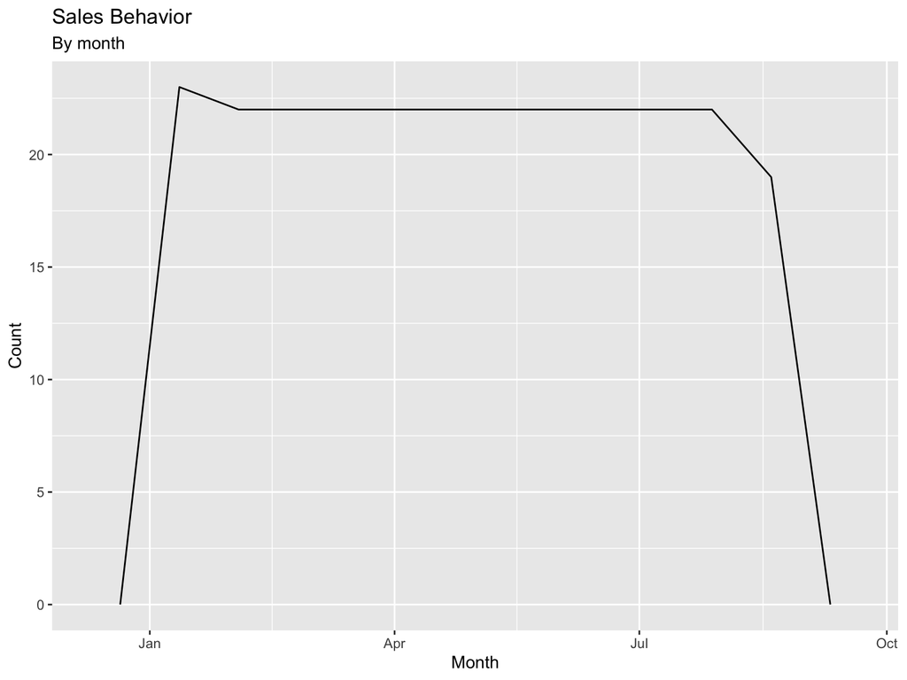

```r
ggplot(data = Online_Sales_Data, aes(x = shop_date)) + geom_freqpoly(binwidth = 22) + ggtitle("Sales Behavior", subtitle = "By month") + labs(x = "Month", y = "Count")
```

# 2) Which category is shopped for the most based off the regions?

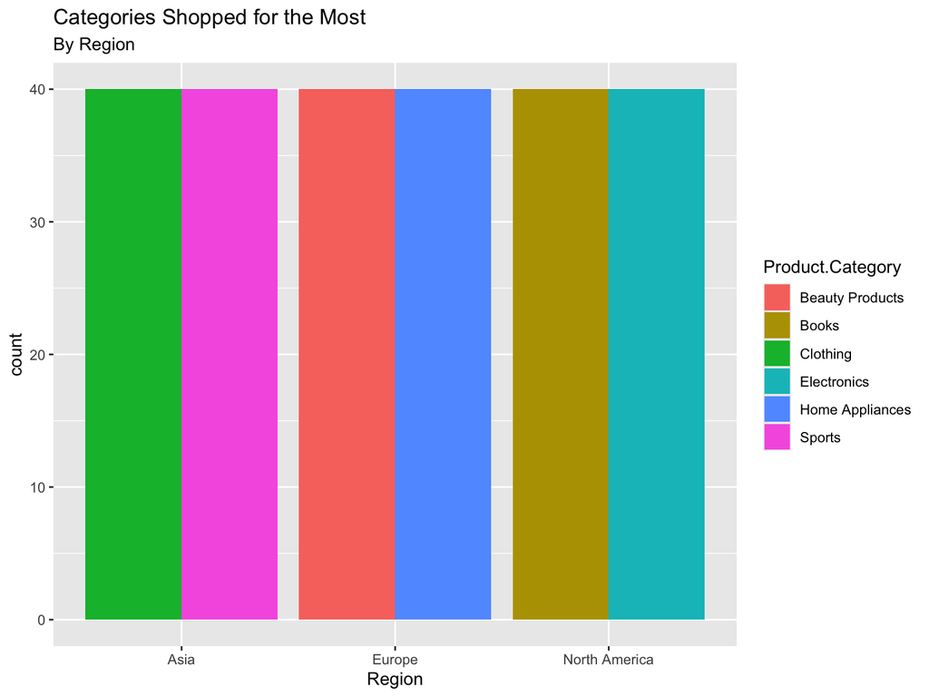

```r
ggplot(data = Online_Sales_Data) + geom_bar(mapping = aes(x = Region, fill = Product.Category), position = "dodge") + ggtitle("Categories Shopped for the Most", subtitle = "By Region")
```

# 3) How does the total revenue vary by regions?

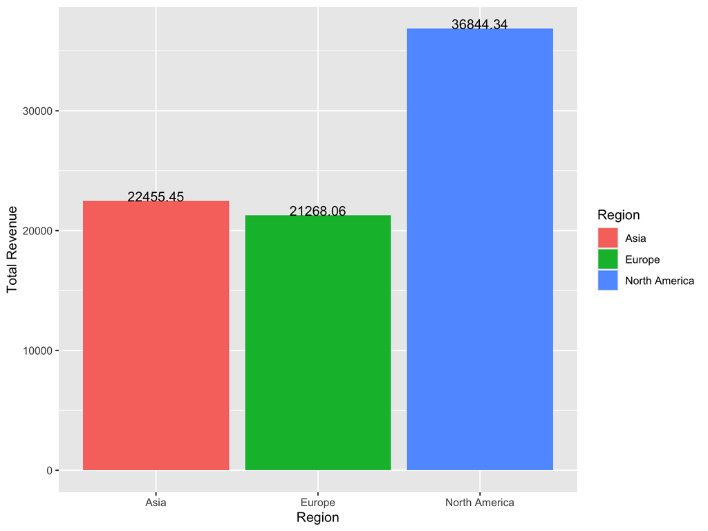

```r
Online_Sales_Data %>%
  group_by(Region) %>%
  summarise(Total_of_Revenue = sum(Total.Revenue)) %>%
  ggplot(aes(x = Region, y = Total_of_Revenue, fill = Region)) +
  geom_col() + geom_text(
    aes(label = Total_of_Revenue, y = Total_of_Revenue + 0.05),
    position = position_dodge(0.8),
    vjust = 0) +
  labs(x = "Region", y = "Total Revenue")
```

# 4) How does the categories differ in behavior by month?

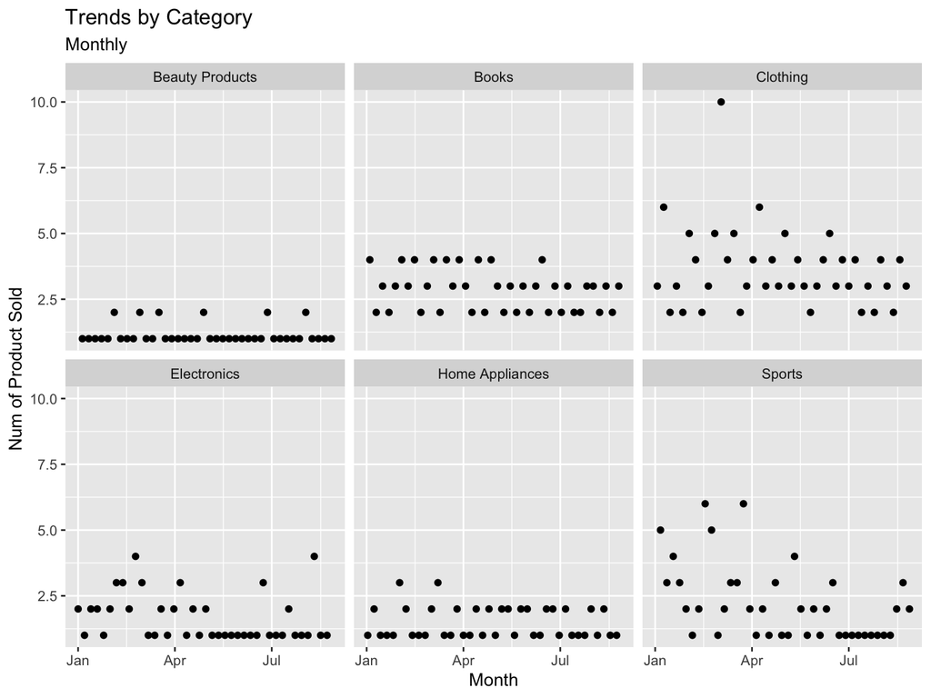

```r
Online_Sales_Data %>%
  group_by(shop_date, Product.Category) %>%
  select(Product.Category, Product.Name, Units.Sold) %>%
  ggplot(aes(x = shop_date, y = Units.Sold)) + geom_point() + facet_wrap(~Product.Category) +
  ggtitle("Trends by Category", subtitle = "Monthly") +
  labs(x = "Month", y = "Num of Product Sold")
```

# 5) How does payment method vary by region?

[figure not shown]

```r
ggplot(Online_Sales_Data) + geom_bar(mapping = aes(x = Region, fill = Payment.Method)) + ggtitle("Payment Methods", subtitle = "By Region")
```

# 6) How does price affect the product categories?

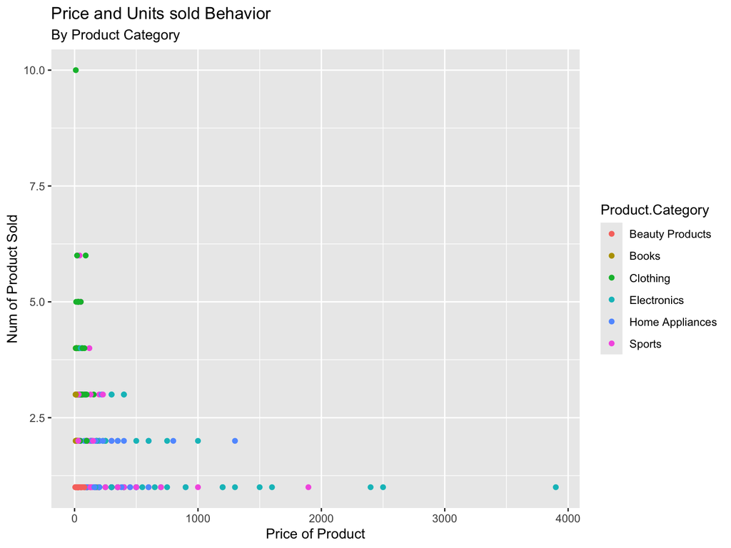

```r
ggplot(data = Online_Sales_Data, aes(x = Unit.Price, y = Units.Sold, color = Product.Category)) + geom_point() + ggtitle("Price and Units sold Behavior", subtitle = "By Product Category") + labs(x = "Price of Product", y = "Num of Product Sold")
```

# 7) How much do people spend on average for each category?

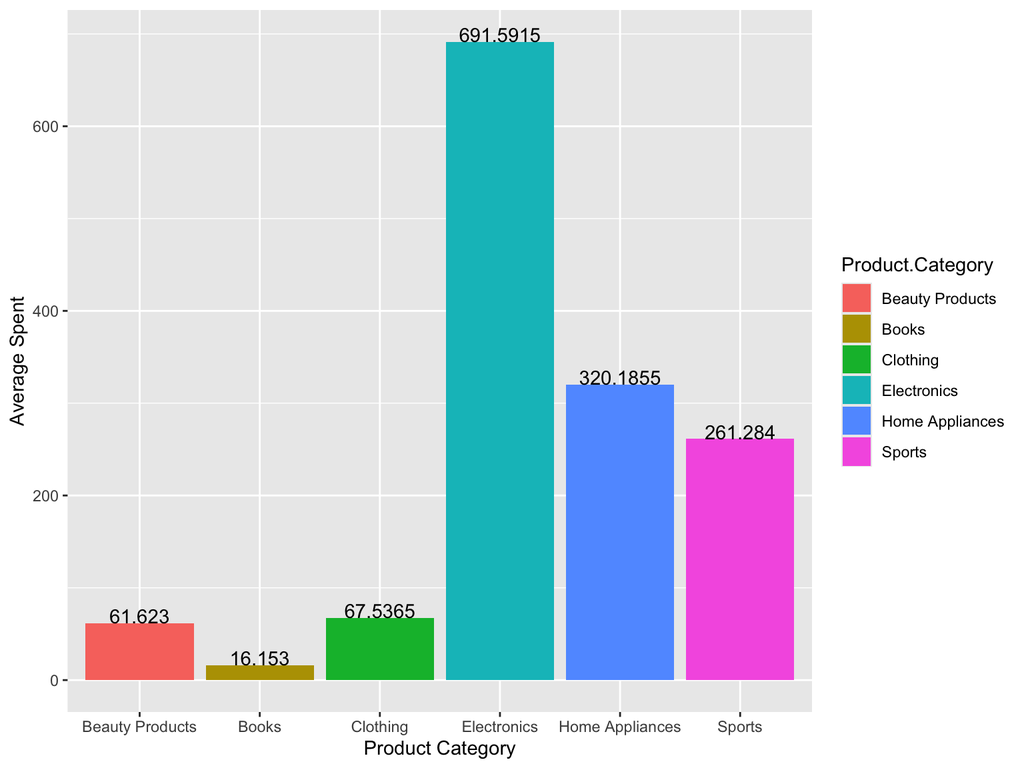

```r
Online_Sales_Data %>%
  group_by(Product.Category) %>%
  summarise(average_spent = mean(Unit.Price)) %>%
  ggplot(aes(x = factor(Product.Category), y = average_spent, fill = Product.Category)) +
  geom_col() + geom_text(
    aes(label = average_spent, y = average_spent + 0.05),
    position = position_dodge(0.8),
    vjust = 0) +
  labs(x = "Product Category", y = "Average Spent")
```

# 8) How much are people spending throughout the time?

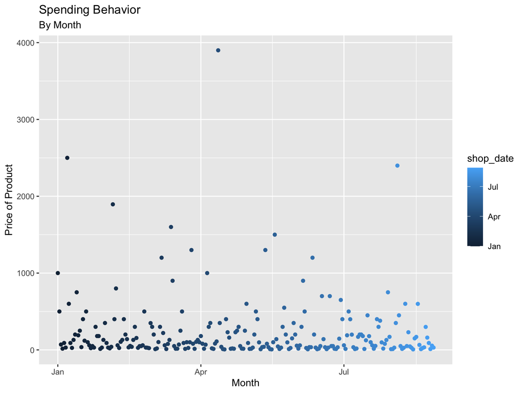

```r
ggplot(data = Online_Sales_Data, aes(x = shop_date, y = Unit.Price, color = shop_date)) + geom_point() + ggtitle("Spending Behavior", subtitle = "By Month") + labs(x = "Month", y = "Price of Product")
```

# Summary)

To summarize, the data showed that North America spends a lot on electronics especially Apple Products. The pricing affects products shown, the pricier an item the less it’s sold.